# US coal exports

Joel Bazzle

03 February 2021

## Preliminaries:

### Load libraries

It’s a good idea to load your libraries at the top of the Rmd document so that everyone can see what you’re using. Similarly, it’s good practice to set `cache=FALSE` to ensure that the libraries are dynamically loaded each time you knit the document.

```r
## Install the pacman package if necessary
if (!require("pacman")) install.packages("pacman")
## Install other packages using pacman::p_load()
pacman::p_load(httr, readxl, here, tidyverse, data.table, janitor, dplyr, viridis, ggthemes, RColorBrewer, gganimate, gifski, png)
```

### Read in the data

Use `httr::GET()` to fetch the EIA excel file for us from web. (We’ll learn more about `httr`, GET and other HTTP methods when we get to webscraping next week.)

```r
# library(here) ## Already loaded
# library(httr) ## Already loaded
url = "https://www.eia.gov/coal/archive/coal_historical_exports.xlsx"
## Only download the file if we need to
if(!file.exists(here::here("data/coal.xlsx"))) {
  GET(url, write_disk(here::here("data/coal.xlsx")))
}
```

```
## Response [https://www.eia.gov/coal/archive/coal_historical_exports.xlsx]
##   Date: 2021-01-31 19:59
##   Status: 200
##   Content-Type: application/vnd.openxmlformats-officedocument.spreadsheetml.sheet
##   Size: 785 kB
## <ON DISK>  /Users/Bazzle/Documents/607 Data Sci Projects/assignment-2-data-wrangling-jbazzle/data/coal.xlsx
```

Next, we read in the file.

```r
# library(readxl) Already loaded
coal = read_excel(here::here("data/coal.xlsx"), skip=3, na=".")
```

We are now ready to go.

## 1) Clean the column names

The column (i.e. variable) names aren’t great: Spacing, uppercase letters, etc.

```r
coal = clean_names(coal)

names(coal)
```

```
##  [1] "year"                     "quarter"
##  [3] "type"                     "customs_district"
##  [5] "coal_origin_country"      "coal_destination_country"
##  [7] "steam_coal"               "steam_revenue"
##  [9] "metallurgical"            "metallurgical_revenue"
## [11] "total"                    "total_revenue"
## [13] "coke"                     "coke_revenue"
```

## 2) Total US coal exports over time (year only)

Plot the US’s total coal exports over time by year ONLY. What secular trends do you notice in the data?

```r
unique(coal$coal_origin_country)
```

```
## [1] "United States"
```

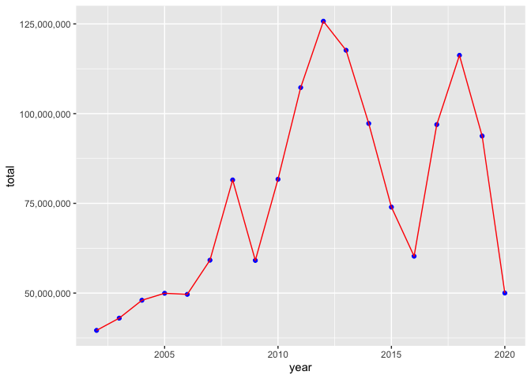

```r
## This is all export data, so that's cool

##multiple observations per year/total is region total
##note to future self: aggregate doesn't play nice with NA littered data, apparently

coalyeartotals = coal %>%
  group_by(year) %>%
  summarize(sum(total, na.rm = T))

colnames(coalyeartotals) = c("year", "total")

coalyeartotals %>%
  ggplot(mapping = aes(x= year, y = total)) +
  geom_point(color = "blue")+
  geom_line(color = "red")+
  scale_y_continuous(labels = scales::comma)
```

**At first glance I thought there was a political trend because of the sudden rise in 2016, but that doesn’t necessarily account for the increase between 2008-2012 and the fall between 2012-2016. Attempts to find anything about domestic coal use from this period seem to be an excellent way to generate ad revenue for Politico whilst wading into their substance-free editorials written by right-wing hacks.**

**That being said, it seems like global demand has been steadily declining in most countries since 2012. The largest outlier in that trend is China, which has significantly increased its coal use. Coal exporters have struggled to increase exports to China because Oregon and Washington have blocked the construction of new export terminals due to obvious environmental concerns that would accompany both the terminal and the rail transport of coal.**

## 3) Total US coal exports over time (year AND quarter)

Now do the same as the above, except aggregated quarter of year (2001Q1, 2002Q2, etc.). Do you notice any seasonality that was masked from the yearly averages?

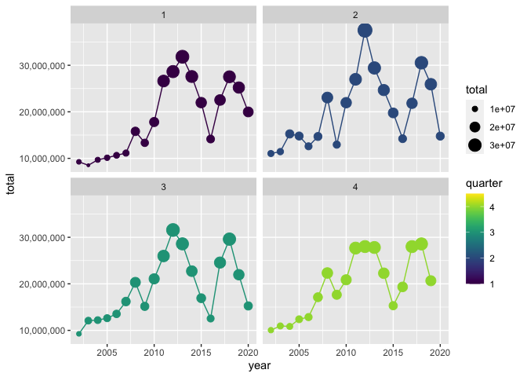

```r
coalquartertotals = coal %>%
  group_by(quarter, year) %>%
  summarize(sum(total, na.rm = T))

colnames(coalquartertotals) = c("quarter", "year", "total")

coalquartertotals %>%
  ggplot() +
  geom_point(aes(x = year, y = total, color = quarter, size = total))+
  geom_line(aes(x = year, y = total, color = quarter))+
  scale_y_continuous(labels = scales::comma)+
  scale_color_viridis(option = "D", limits = c(1, 4.5))+
  facet_wrap(~ quarter)
```

```r
## Note for future self: coerce these god awful, incoherent, colorblind unfriendly pallets using limits = (interval)
```

**It looks like quarter 2 2012 was the actual export peak, and the fall began in quarter 3 2012. Additionally, it looks like the most coal is generally exported in quarter 2**

## 4) Exports by destination country

### 4.1) Create a new data frame

Create a new data frame called `coal_country` that aggregates total exports by destination country (and quarter of year). Make sure you print the resulting data frame so that it appears in the knitted R markdown document.

```r
coal_country = coal %>%
  group_by(year, quarter, coal_destination_country) %>%
   summarize(sum(total, na.rm = T))

colnames(coal_country) = c("year", "quarter", "destination", "total")

coal_country
```

```
## # A tibble: 4,574 x 4
## # Groups:   year, quarter [75]
##     year quarter destination   total
##    <dbl>   <dbl> <chr>         <dbl>
##  1  2002       1 Algeria      129305
##  2  2002       1 Angola         5713
##  3  2002       1 Argentina     40159
##  4  2002       1 Australia       175
##  5  2002       1 Belgium      575556
##  6  2002       1 Brazil       709171
##  7  2002       1 Canada      2270612
##  8  2002       1 Chile           812
##  9  2002       1 China             0
## 10  2002       1 Colombia        703
## # … with 4,564 more rows
```

### 4.2) Inspect the data frame

It looks like some countries are missing data for a number of years and periods (e.g. Albania). Confirm that this is the case. What do you think is happening here?

```r
frequencytable = coal_country %>% plyr::count("destination")
frequencytable
```

```
##                                destination freq
## 1                                  Albania    1
## 2                                  Algeria   46
## 3                                  Andorra    1
## 4                                   Angola   43
## 5                                 Anguilla    1
## 6                      Antigua and Barbuda    2
## 7                                Argentina   72
## 8                                  Armenia    4
## 9                                    Aruba    7
## 10                               Australia   61
## 11                                 Austria   57
## 12                              Azerbaijan    6
## 13                                 Bahamas   27
## 14                                 Bahrain    1
```

[output cut: 137 more lines]

**Based only on the first page output (conveniently containing Albania), it is clear that the frequency with which countries appear in the data varies significantly. A reasonable explanation, I would think, is that exporters are not consistently exporting to every country on the list during every quarter of every year. Albania, for instance, only imported US coal once**

### 4.3) Complete the data frame

Fill in the implicit missing values, so that each country has a representative row for every year-quarter time period. In other words, you should modify the data frame so that every destination country has row entries for all possible year-quarter combinations (from 2002Q1 through the most recent quarter). Order your updated data frame by country, year and, quarter.

```r
coal_country = coal_country %>%  ungroup() %>%
  complete(quarter, year, destination, fill = list(total = 0))

coal_country
```

```
## # A tibble: 11,476 x 4
##    quarter  year destination          total
##      <dbl> <dbl> <chr>                <dbl>
##  1       1  2002 Albania                  0
##  2       1  2002 Algeria             129305
##  3       1  2002 Andorra                  0
##  4       1  2002 Angola                5713
##  5       1  2002 Anguilla                 0
##  6       1  2002 Antigua and Barbuda      0
##  7       1  2002 Argentina            40159
##  8       1  2002 Armenia                  0
##  9       1  2002 Aruba                    0
## 10       1  2002 Australia              175
## # … with 11,466 more rows
```

**make sure that worked…**

```r
frequencytable2 = coal_country %>% plyr::count("destination")
frequencytable2
```

```
##                                destination freq
## 1                                  Albania   76
## 2                                  Algeria   76
## 3                                  Andorra   76
## 4                                   Angola   76
## 5                                 Anguilla   76
## 6                      Antigua and Barbuda   76
## 7                                Argentina   76
## 8                                  Armenia   76
## 9                                    Aruba   76
## 10                               Australia   76
## 11                                 Austria   76
## 12                              Azerbaijan   76
## 13                                 Bahamas   76
## 14                                 Bahrain   76
```

[output cut: 137 more lines]

### 4.4 Some more tidying up

In answering the previous question, you *may* encounter a situation where the data frame contains a quarter — probably 2020q4 — that is missing total export numbers for *all* countries. Did this happen to you? Filter out the completely missing quarter if so. Also: Why do you think this might have happened? (Please answer the latter question even if it didn’t happen to you.)

```r
gsub("\\.", "q", lubridate::quarter(Sys.Date()-months(3), with_year = TRUE))
```

```
## [1] "2020q4"
```

**Complete() is finding all possible combinations of quarter, year, and destination. We don’t have data for 2020q4 in the data set, but 2020q4 is a possible combination, so when the complete function ran it generated rows for it.**

```r
coal_country = coal_country %>%
  filter(!(year == 2020 & quarter == 4))

coal_country
```

```
## # A tibble: 11,325 x 4
##    quarter  year destination          total
##      <dbl> <dbl> <chr>                <dbl>
##  1       1  2002 Albania                  0
##  2       1  2002 Algeria             129305
##  3       1  2002 Andorra                  0
##  4       1  2002 Angola                5713
##  5       1  2002 Anguilla                 0
##  6       1  2002 Antigua and Barbuda      0
##  7       1  2002 Argentina            40159
##  8       1  2002 Armenia                  0
##  9       1  2002 Aruba                    0
## 10       1  2002 Australia              175
## # … with 11,315 more rows
```

**Looks like it is fixed now**

### 4.5) Culmulative top 10 US coal export destinations

Produce a vector — call it `coal10_culm` — of the top 10 top coal destinations over the full study period. What are they?

```r
coal_cum = coal_country %>%
  group_by(destination) %>%
   summarize(sum(total, na.rm = T))

colnames(coal_cum) = c("destination", "total")

coal_cum = coal_cum[order(-coal_cum$total),]

coal_culm = coal_cum[1:10, 1]

coal_culm
```

```
## # A tibble: 10 x 1
##    destination
##    <chr>
##  1 Canada
##  2 Netherlands
##  3 Brazil
##  4 India
##  5 South Korea (Republic of Korea)
##  6 United Kingdom
##  7 Japan
##  8 Italy
##  9 Germany, Federal Republic of
## 10 Mexico
```

**The country list above represents the top ten buyers of US coals over the entire period.**

### 4.6) Recent top 10 US coal export destinations

Now do the same, except for most recent period on record (i.e. final quarter in the dataset). Call this vector `coal10_recent` and make sure to print it so that I can see it too. Are there any interesting differences between the two vectors? Apart from any secular trends, what else might explain these differences?

```r
coal_recent = coal_country %>%
  filter((year == 2020 & quarter == 3))


coal10_recent = coal_recent[order(-coal_recent$total),]

coal10_recent = coal10_recent[1:10, 3]

coal10_recent
```

```
## # A tibble: 10 x 1
##    destination
##    <chr>
##  1 India
##  2 Brazil
##  3 Netherlands
##  4 Canada
##  5 Japan
##  6 South Korea (Republic of Korea)
##  7 Turkey
##  8 Ukraine
##  9 Dominican Republic
## 10 Austria
```

**Many of the differences are not surprising (Germany and the UK not being in the top ten, India being at the top). Ukraine being in the top ten is pretty interesting. I imagine they’ve shifted a fair portion of their energy dependence to the US in light of their closest trading partner launching an invasion and annexing part of their territory. I also would have thought that Japan and South Korea would have been on a similar trajectory to the UK and Germany in terms of coal use, but this serves as evidence that assumption may not be correct.**

### 4.7) US coal exports over time by country

Plot the quarterly coal exports over time, but now disaggregated by country. In particular, highlight the top 10 (cumulative) export destinations and then sum the remaining countries into a combined “Other” category. (In other words, your figure should contain the time series of eleven different countries/categories.)

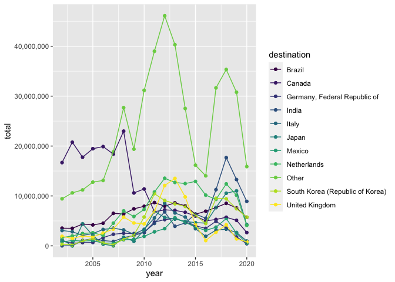

```r
coalbycountry = coal_country

coalbycountry$destination = ifelse(coalbycountry$destination %in% coal_culm$destination, coalbycountry$destination, "Other")

coalbycountry = coalbycountry %>%
  group_by(year, destination) %>%
  summarize(sum(total, na.rm = T))

colnames(coalbycountry) = c("year", "destination", "total")

coalbycountry %>%
  ggplot() +
  geom_point(aes(x = year, y = total, color = destination))+
  geom_line(aes(x = year, y = total, color = destination))+
  scale_y_continuous(labels = scales::comma)+
  scale_color_viridis(discrete = T, option = "D")
```

**As someone that loves pasta, let me be the first to say that this spaghetti looks disgusting**

### 4.8) Make it pretty

Take your previous plot and add some swag to it. That is, try to make it as visually appealing as possible without overloading it with chart junk.

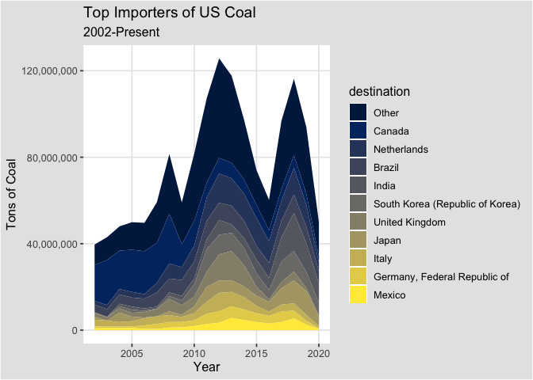

```r
coalbycountry$destination = factor(coalbycountry$destination, levels = c("Other", "Canada", "Netherlands", "Brazil", "India", "South Korea (Republic of Korea)", "United Kingdom", "Japan", "Italy", "Germany, Federal Republic of", "Mexico"))

coalbycountry %>%
  ggplot(aes(x = year, y = total, fill = destination)) +
  geom_area()+
  scale_y_continuous(labels = scales::comma)+
  scale_fill_viridis(discrete = T, option = "cividis")+
  ggtitle("Top Importers of US Coal", subtitle= "2002-Present")+
  xlab("Year")+
  ylab("Tons of Coal")+
  theme_igray()
```

**To me, a stacked-area representation is a lot more coherent. Lasagna does tend to be a bit more appealing than spaghetti, after all**

### 4.9) Make it interactive

**I opted for an animated histogram. I think it is quite interesting to see the rather explosive growth in “other” after 2009 compared to the trends in the top countries.**

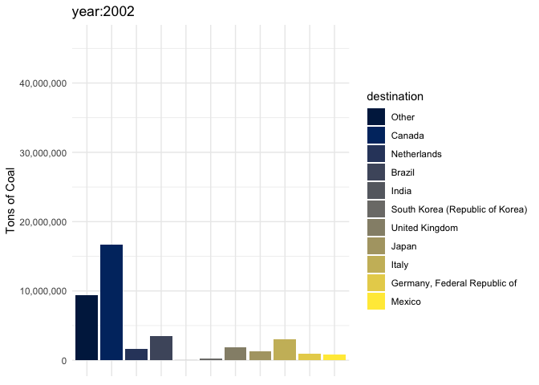

```r
barplot = coalbycountry %>%
  ggplot(aes(x = destination, y = total, fill = destination)) +
  geom_bar(stat = 'identity')+
  scale_y_continuous(labels = scales::comma)+
  scale_fill_viridis(discrete = T, option = "cividis")+
  theme_minimal()+
  theme(axis.title.x=element_blank(), axis.text.x=element_blank(), axis.ticks.x=element_blank())+
  labs(title = 'year:{frame_time}', x = 'Country', y = 'Tons of Coal')+
  transition_time(year)+
  ease_aes('linear')

animate(barplot)
```

## 5) Show me something interesting

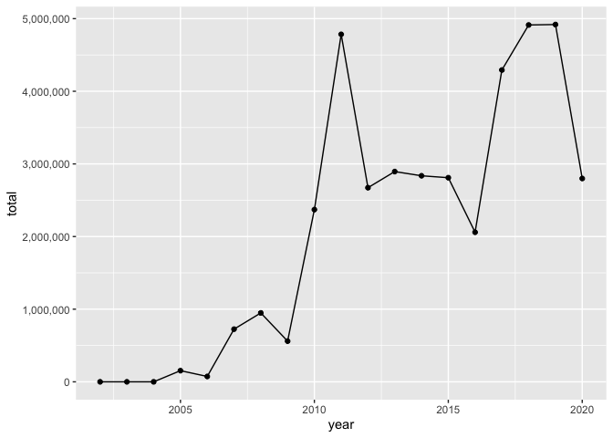

```r
ukrainedata = coal_country %>%
  filter(destination == "Ukraine")

ukrainedata = ukrainedata %>%
  group_by(year) %>%
  summarize(sum(total, na.rm = T))

colnames(ukrainedata) = c("year", "total")

ukrainedata %>%
  ggplot() +
  geom_point(aes(x = year, y = total))+
  geom_line(aes(x = year, y = total))+
  scale_y_continuous(labels = scales::comma)
```